# GapMinder_Analysis

Haneef Meeran

6/16/2019

## Question

*To measure the Income and Life expectance rate in different Geographic locations*

### Data Description

- Country describes the primary variable describes the location of the life expectancy measured
- Region describes the continent related to the country
- Year - Provided for each country from 1800 to 2015
- Life - Provided for each country by year
- Population - Data available for each starting decade of each country
- Income - Continous data series for each country by year

###### *Income - Gross domestic product per person adjusted for differences in purchasing power (GDP/capita, PPP$ inflation adjusted)*

###### *Life - The average number of years a newborn child would live if current mortality pattern were to stay the same*

###### *population - Population for the given country in the given year [(Source: GapMinder)](https://www.gapminder.org/data/)*

## Data Preparation

Set working directory

Import the Raw data

Adding Required libraries

Summary of Data

Explore Data Analysis

### Set working directory and Import raw data

```r
setwd("~/Desktop/EXPL DATA ANALYSIS/EDA REPORT")

gapminder <- read.csv("gapminder.csv")
```

### Required Libraries

```r
library(dplyr)
```

```r
library(ggplot2)

library(matrixStats)
library(scales)
```

### Summary of data

```r
#Summary of  Gapminder
summary(gapminder)
```

```
##                 Country           Year           life
##  Afghanistan        :  216   Min.   :1800   Min.   : 1.00
##  Albania            :  216   1st Qu.:1854   1st Qu.:31.00
##  Algeria            :  216   Median :1908   Median :35.12
##  Angola             :  216   Mean   :1907   Mean   :42.88
##  Antigua and Barbuda:  216   3rd Qu.:1962   3rd Qu.:55.60
##  Argentina          :  216   Max.   :2015   Max.   :84.10
##  (Other)            :39988
##    population        income                              region
##         :25817   Min.   :   142   America                   : 7961
##  121000 :    6   1st Qu.:   883   East Asia & Pacific       : 6256
##  14092  :    6   Median :  1450   Europe & Central Asia     :10468
##  1432000:    6   Mean   :  4571   Middle East & North Africa: 4309
##  229000 :    6   3rd Qu.:  3483   South Asia                : 1728
##  2574000:    6   Max.   :182668   Sub-Saharan Africa        :10562
##  (Other):15437   NA's   :2341
```

```r
str(gapminder)
```

```
## 'data.frame':    41284 obs. of  6 variables:
##  $ Country   : Factor w/ 197 levels "Afghanistan",..: 1 1 1 1 1 1 1 1 1 1 ...
##  $ Year      : int  1800 1801 1802 1803 1804 1805 1806 1807 1808 1809 ...
##  $ life      : num  28.2 28.2 28.2 28.2 28.2 ...
##  $ population: Factor w/ 15260 levels "","1,005,328,574",..: 7490 1 1 1 1 1 1 1 1 1 ...
##  $ income    : int  603 603 603 603 603 603 603 603 603 603 ...
##  $ region    : Factor w/ 6 levels "America","East Asia & Pacific",..: 5 5 5 5 5 5 5 5 5 5 ...
```

```r
#Number of Unique Countries
length(unique(gapminder$Country))
```

```
## [1] 197
```

```r
#Cleaning of population field. Removing commas and reloading as numeric in a different dataset without NAs.
gapminder$population1 <- as.numeric(gsub(",","",gapminder$population))


gapminder1 <- gapminder %>% filter(!is.na(gapminder$population1))
```

## Analysis

### Income

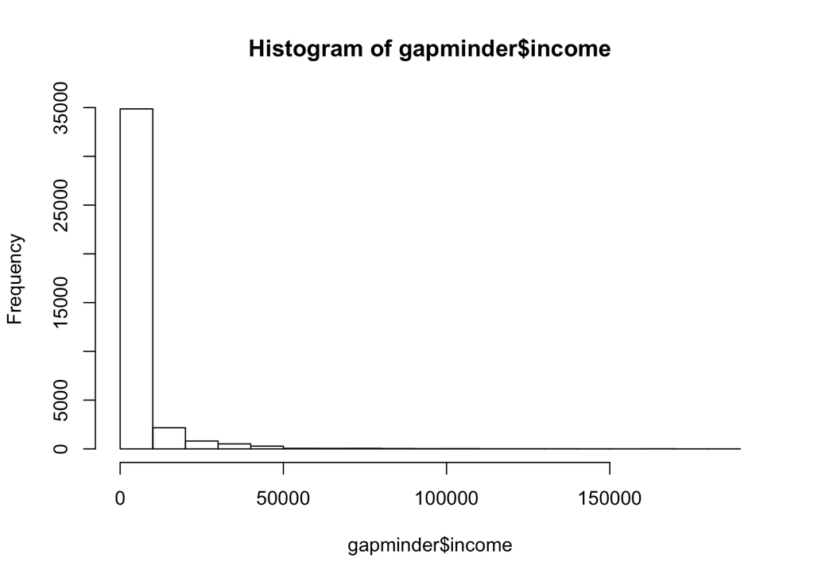

```r
hist(gapminder$income)
```

```r
summary(unique(gapminder$income))
```

```
##    Min. 1st Qu.  Median    Mean 3rd Qu.    Max.    NA's
##     142    2978    6651   12397   14744  182668       1
```

```r
weightedMedian(gapminder$income, w = gapminder$region, na.rm = TRUE)
```

```
## [1] 1182
```

```r
weightedMean(gapminder$income, w = gapminder$region, na.rm = TRUE)
```

```
## [1] 3900.356
```

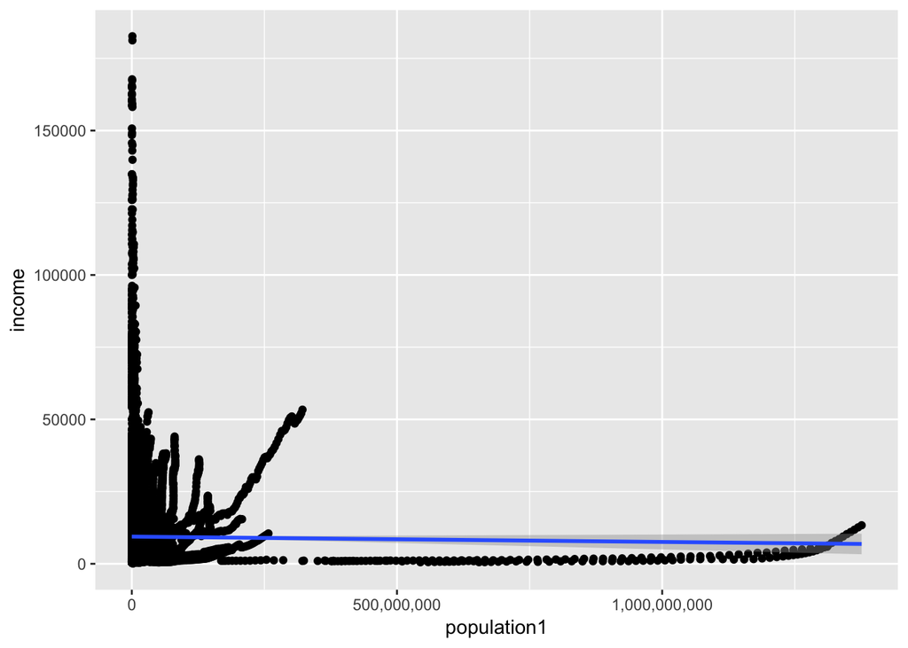

```r
d <- ggplot(gapminder1, aes(x = population1, y = income))
d + geom_point()+geom_smooth(method = "lm") + scale_x_continuous(labels = scales::comma)
```

###Life Expectancy

Let’s look at the frequencies of the life expectancy and income ranges for the complete data

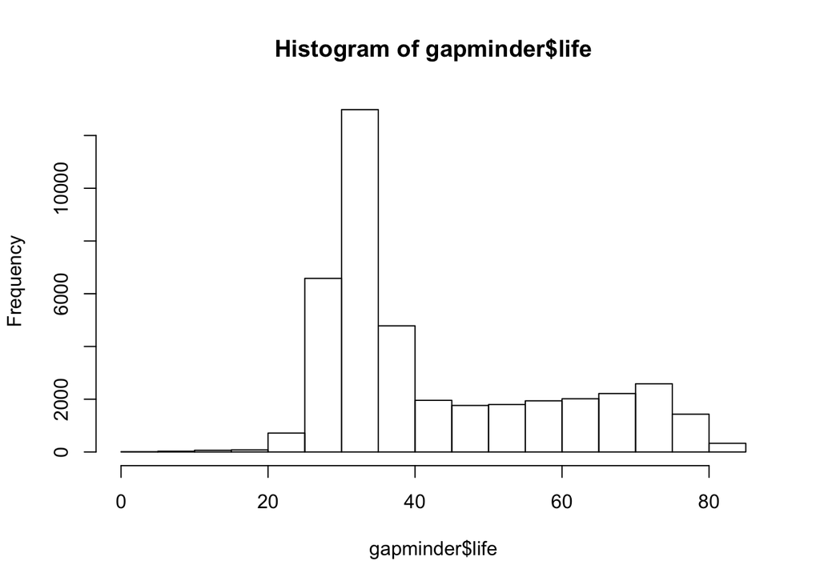

```r
hist(gapminder$life)
```

```r
summary(gapminder$life)
```

```
##    Min. 1st Qu.  Median    Mean 3rd Qu.    Max.
##    1.00   31.00   35.12   42.88   55.60   84.10
```

```r
weightedMedian(gapminder$life, w = gapminder$region, na.rm = TRUE)
```

```
## [1] 33.86702
```

```r
weightedMean(gapminder$life, w = gapminder$region, na.rm = TRUE)
```

```
## [1] 41.45024
```

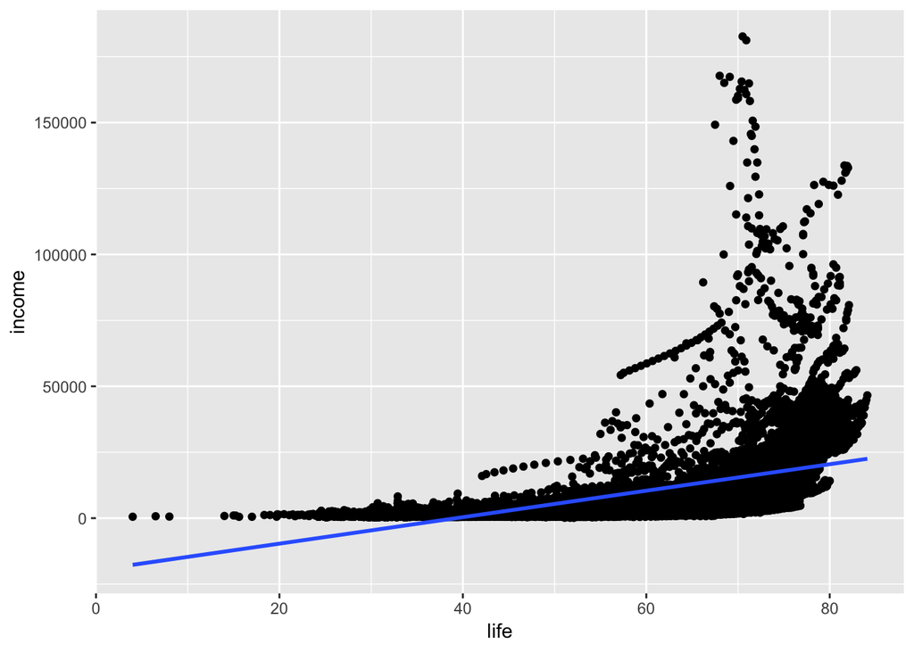

```r
e <- ggplot(gapminder1, aes(x = life, y = income))
e + geom_point()+geom_smooth(method = "lm") + scale_x_continuous(labels = scales::comma)
```

There seems to be a high frequency of *life expectancy* in the range of **25-35 years**  
In the next graph, we can see that the life expectancy grows regardless of the income growth. However, as the life expectancy grows past 60, there is a big growth in income.

### Population

```r
median(gapminder1$population1)
```

```
## [1] 3358089
```

```r
mean(gapminder1$population1)
```

```
## [1] 21187964
```

```r
weightedMedian(gapminder1$population1, w = gapminder1$Country, na.rm = TRUE)
```

```
## [1] 3474657
```

```r
weightedMean(gapminder1$population1, w = gapminder1$Country, na.rm = TRUE)
```

```
## [1] 19078834
```

```
p <- ggplot(gapminder1, aes(reorder(region, population1, FUN=function(x) mean(log10(x))), population1))
p <- p + scale_y_log10()
p + geom_boxplot(outlier.colour="red") + geom_jitter(alpha=1/2)
```

## Working with Country data

### Comparison between India and China

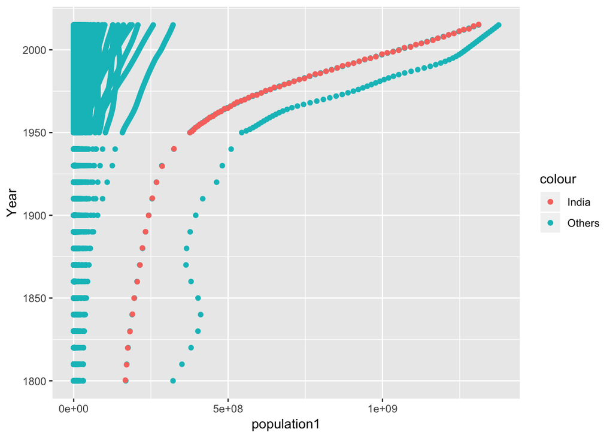

```r
# Creating subset of India Country
population_india <- gapminder1 %>% filter(Country=='India')
# Creating subset of India Country
population_china <- gapminder1 %>% filter(Country=='China')

ggplot(data= population_india, mapping = aes(y=Year, x=population1, color="India"))  + geom_point(data = gapminder1, aes(color="Others")) + geom_jitter()
```

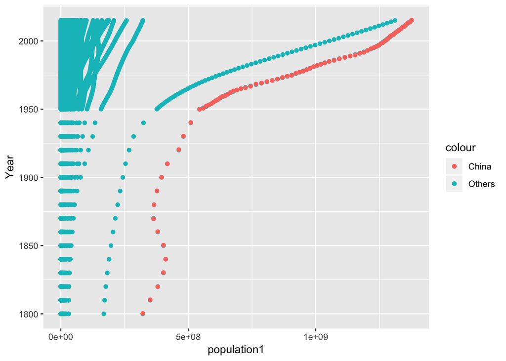

```r
ggplot(data= population_china, mapping = aes(y=Year, x=population1, color="China")) + geom_point(data = gapminder1, aes(color="Others")) + geom_jitter()
```

The population in India and China has risen exponentially after 1950 as compared to other countries.

### India and China after 1950

```r
gapminder1 %>% #Filtering data for India
 filter(Country=='India') %>%
summarize('LifeExpected (Mean) in India'=mean(population1),
 'Population (Standard Deviation) in India'=sd(population1))
```

| LifeExpected (Mean) in India | Population (Standard Deviation) in India |
| --- | --- |
| 675758566 | 343006329 |

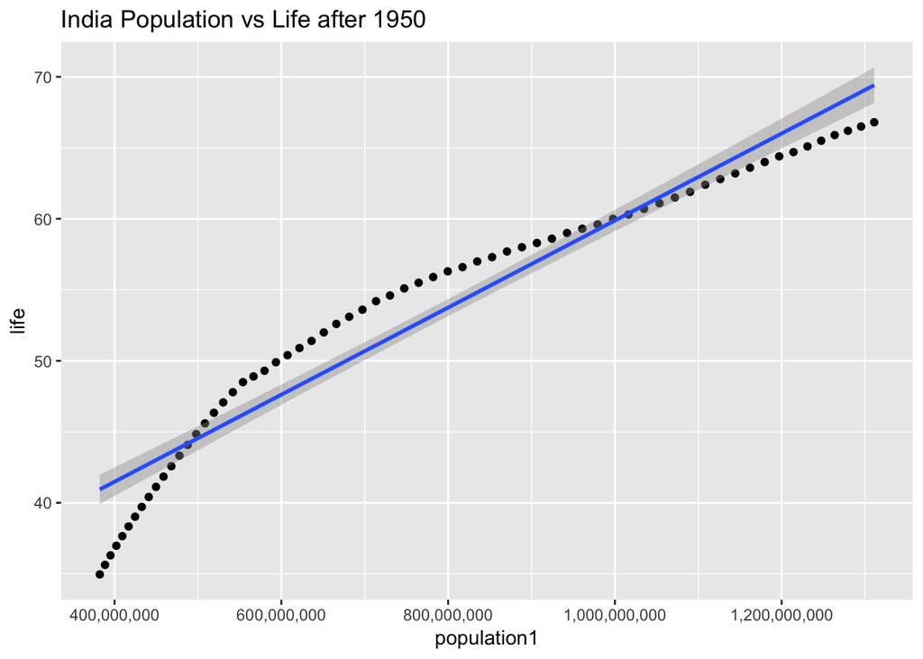

```r
#Filtering data for India after 1950
pop_ind_after_1950 <- population_india %>% filter(Year > '1950')

b <- ggplot(pop_ind_after_1950, aes(x = population1, y = life))
b + geom_point()+geom_smooth(method = "lm") + scale_x_continuous(labels = scales::comma) + labs(title="India Population vs Life after 1950")
```

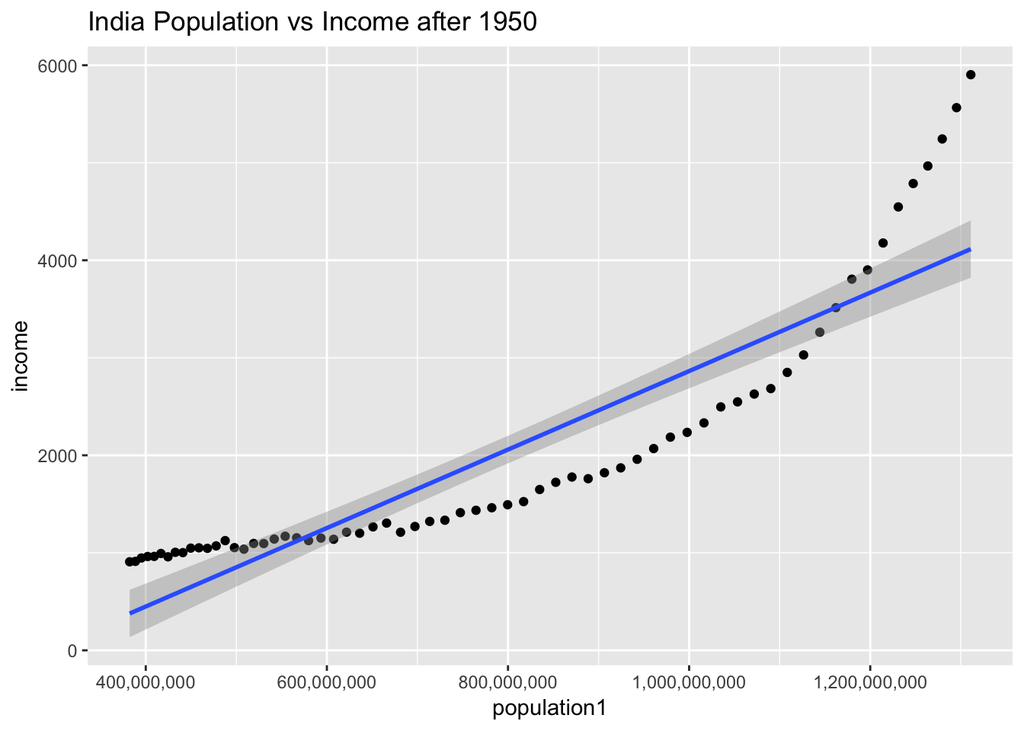

```r
c <- ggplot(pop_ind_after_1950, aes(x = population1, y = income))
c + geom_point()+geom_smooth(method = "lm") + scale_x_continuous(labels = scales::comma) + labs(title="India Population vs Income after 1950")
```

```r
gapminder1 %>%filter(Country=='China') %>%#Filtering data for India
summarize('LifeExpected (Mean) in China'=mean(population1),
 'Population (Standard Deviation) in China'=sd(population1))
```

| LifeExpected (Mean) in China | Population (Standard Deviation) in China |
| --- | --- |
| 886011895 | 340405516 |

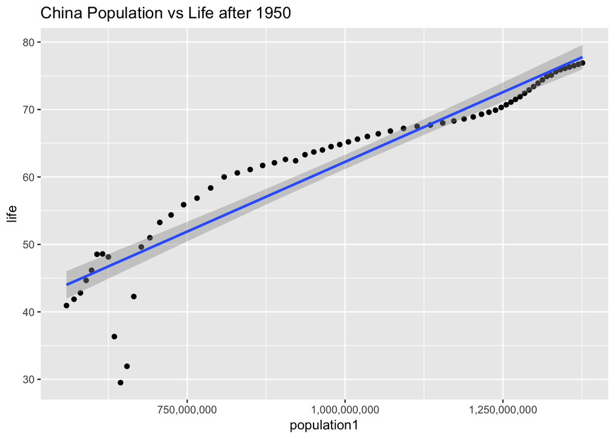

```r
#Filtering data for India after 1950
pop_chn_after_1950 <- population_china %>% filter(Year > '1950')

b <- ggplot(pop_chn_after_1950, aes(x = population1, y = life))
b + geom_point()+geom_smooth(method = "lm") + scale_x_continuous(labels = scales::comma) + labs(title="China Population vs Life after 1950")
```

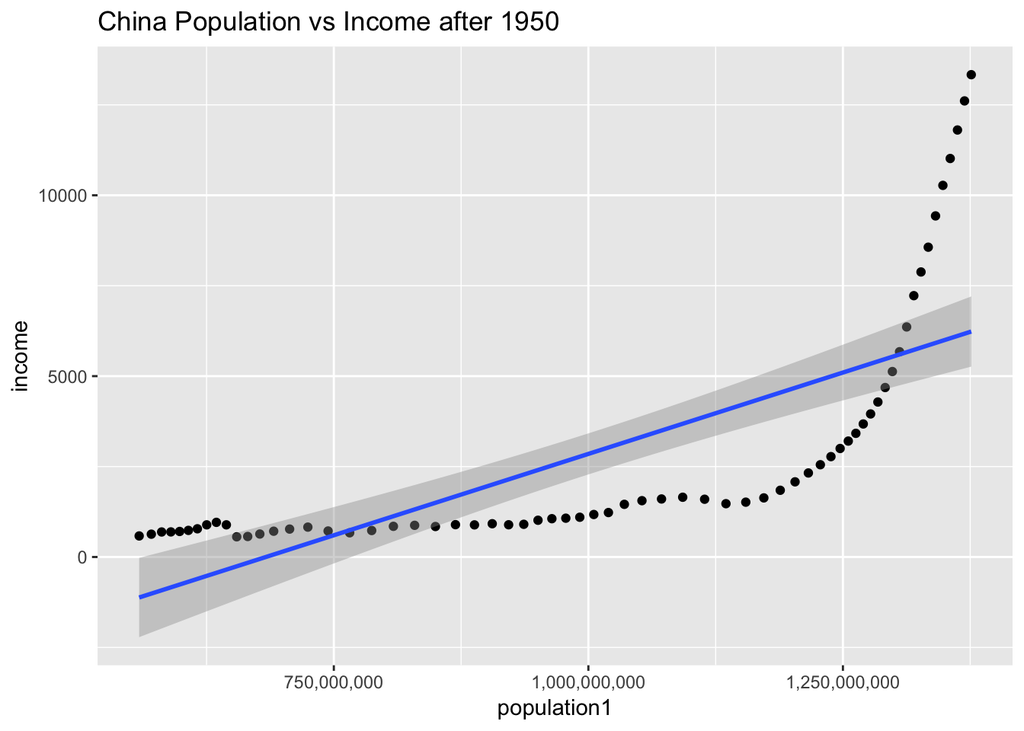

```r
c <- ggplot(pop_chn_after_1950, aes(x = population1, y = income))
c + geom_point()+geom_smooth(method = "lm") + scale_x_continuous(labels = scales::comma)  + labs(title="China Population vs Income after 1950")
```

We can see here there income rose for China and India after population crossed 1.1 billion. However, the rise in life expectancy reduced when the population crossed 600 million and flattened between 55 to 65 years.

## Working with 2015 data

```r
#Creating a dataset with 2015 data
gapminder_2015 <- gapminder %>%
  filter(Year==2015)
# Overview of 2015 data
summary(gapminder_2015)
```

```
##                 Country         Year           life
##  Afghanistan        :  1   Min.   :2015   Min.   :48.50
##  Albania            :  1   1st Qu.:2015   1st Qu.:65.35
##  Algeria            :  1   Median :2015   Median :73.50
##  Andorra            :  1   Mean   :2015   Mean   :71.76
##  Angola             :  1   3rd Qu.:2015   3rd Qu.:77.97
##  Antigua and Barbuda:  1   Max.   :2015   Max.   :84.10
##  (Other)            :172
##          population      income                              region
##               :  1   Min.   :   624   America                   :31
##  1,376,048,943:  1   1st Qu.:  3715   East Asia & Pacific       :25
##  10,349,803   :  1   Median : 11360   Europe & Central Asia     :48
##  10,954,617   :  1   Mean   : 17717   Middle East & North Africa:19
##  100699395    :  1   3rd Qu.: 24290   South Asia                : 8
##  104460       :  1   Max.   :132877   Sub-Saharan Africa        :47
##  (Other)      :172
##   population1
##  Min.   :5.299e+04
##  1st Qu.:2.235e+06
##  Median :8.545e+06
##  Mean   :4.050e+07
##  3rd Qu.:2.851e+07
##  Max.   :1.376e+09
##  NA's   :1
```

Let us take a case for a single *year (2015)* and see at the income range and life expectancy comparison with respect to regions.

### Income in 2015

[figure not shown]

```r
#Plotting 2015 data with income vs region
ggplot(gapminder_2015, aes(x = income, y = region)) + facet_wrap(~Year) +
 geom_boxplot(outlier.colour = 'red') +
 ggtitle('Box plots of Income for continents in 2015 across all countries') +
 geom_jitter(position = position_jitter(width = 0.09, height = 0), alpha = 1/10) + scale_x_continuous(labels = scales::comma)
```

### Life Expectancy in 2015

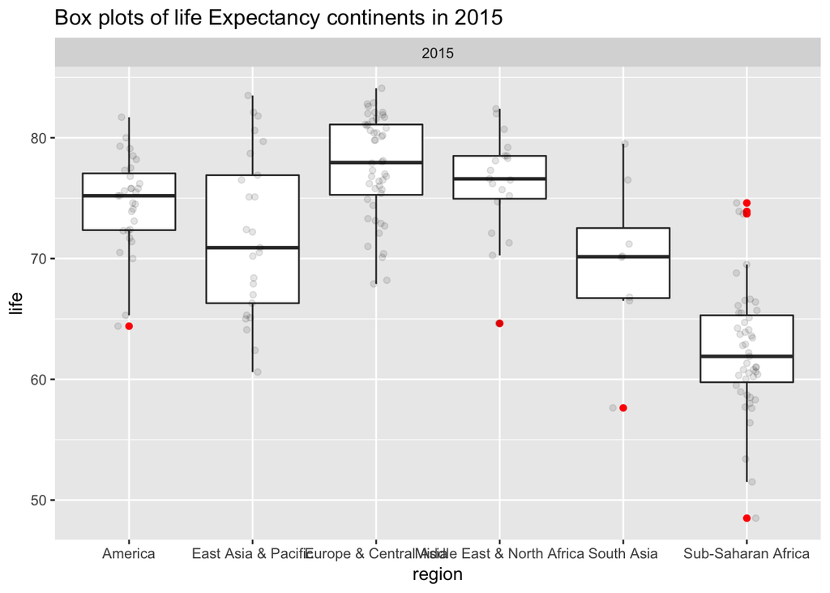

```r
# Regions with life expectancy mean
ggplot(gapminder_2015, aes(x = region, y = life)) + facet_wrap(~Year) +
 geom_boxplot(outlier.colour = 'red') + # extreme values marked red
 ggtitle('Box plots of life Expectancy continents in 2015') +
 geom_jitter(position = position_jitter(width = 0.09, height = 0), alpha = 1/10)
```

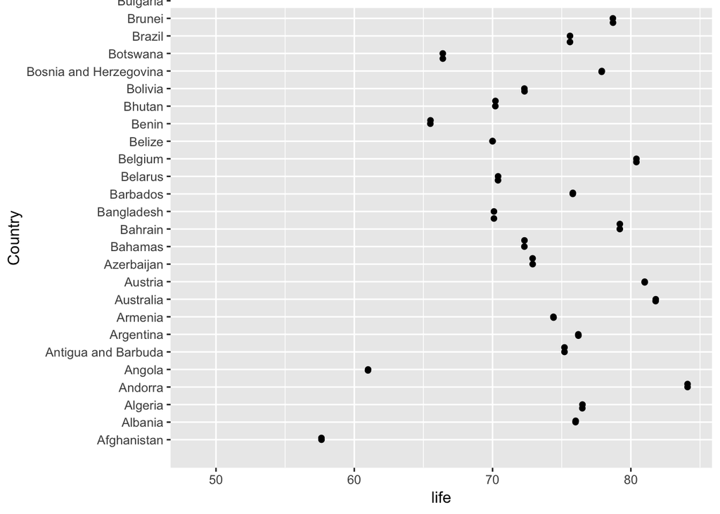

```r
#List of countries with life expectancy in 2015 arranged in descending order
life_gap_2015 <- gapminder_2015 %>%   group_by(Country) %>%   summarize(life) %>%   arrange(desc(life))
ggplot(data= life_gap_2015, mapping = aes(y=Country, x=life))+   geom_point()+   geom_jitter()+   coord_cartesian(ylim=c(0, 25))
```

```r
gapminder_2015 %>% # For each continent in 2015
 group_by(region) %>%
 summarize('Standard Deviation'=sd(life),
 'Inter Quartile Range'=IQR(life),
 'Number'=n())
```

| region | Standard Deviation | Inter Quartile Range | Number |
| --- | --- | --- | --- |
| America | 3.853729 | 4.700 | 31 |
| East Asia & Pacific | 6.745351 | 10.600 | 25 |
| Europe & Central Asia | 4.200260 | 5.825 | 48 |
| Middle East & North Africa | 4.313097 | 3.550 | 19 |
| South Asia | 6.646038 | 5.800 | 8 |
| Sub-Saharan Africa | 5.140874 | 5.545 | 47 |

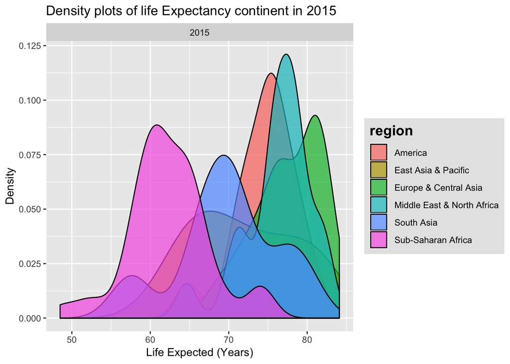

```r
gapminder_2015 %>%
 ggplot(aes(x = life, fill = region)) + facet_wrap(~Year) + # aes = aesthetics
 geom_density(alpha = 0.7) +
 ggtitle('Density plots of life Expectancy continent in 2015') +
 theme(legend.title = element_text(color = 'Black',size = 14, face = 'bold'),
 legend.background = element_rect(fill = 'gray90', size = 0.5, linetype = 'dashed')) +
 labs(x='Life Expected (Years)', y='Density')
```

### Life Expectancy for America in 2015

Let us focus on a single region and in it a single country. Here, the example considered is the region of **America** and the country sample is **United States**.

Calucating the standard deviation for America in 2015:

```r
gapminder_2015 %>% #compute stats
 filter(region=='America') %>%
summarize('LifeExpectancy (Mean) in America for 2015'=mean(life),
 'LifeExpectancy (Standard Deviation) in America for 2015'=sd(life))
```

| LifeExpectancy (Mean) in America for 2015 | LifeExpectancy (Standard Deviation) in America for 2015 |
| --- | --- |
| 74.64516 | 3.853729 |

### America and United States in 2015

```r
# Creating subset of America region
life_America <- gapminder %>% filter(region=='America')
# Creating subset of United States country
life_USA <- gapminder %>%   filter(Country=='United States')
```

#### Plotting Life Expectancy in 2015:

- America region vs other region in world
- United States country vs other countries in America

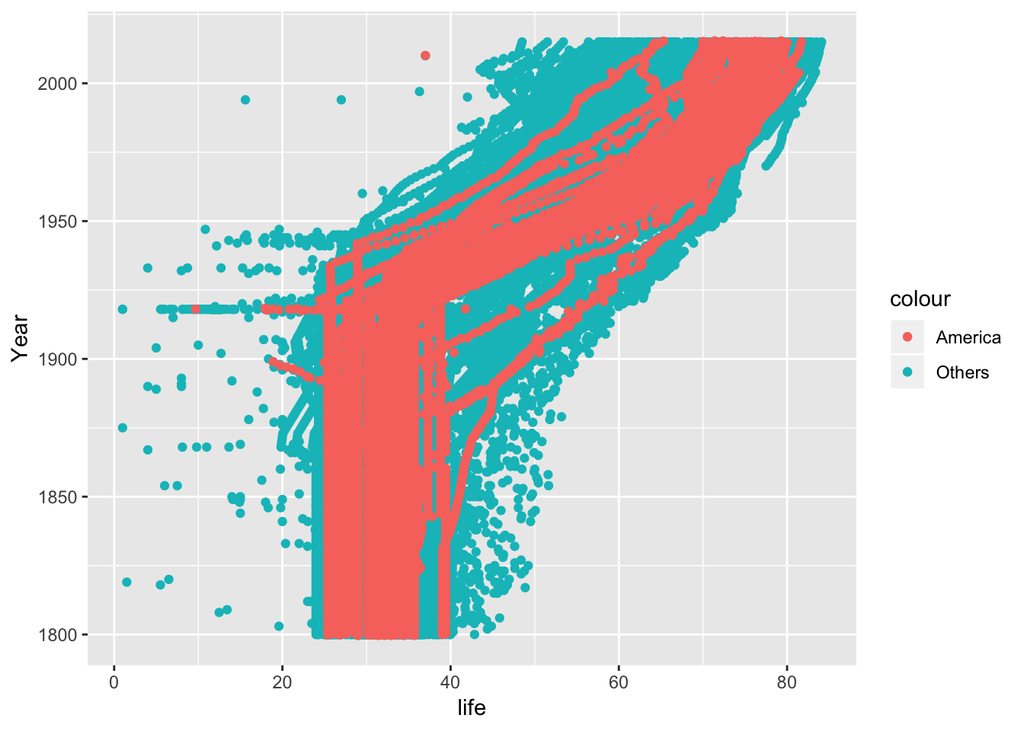

```r
ggplot(data= life_America, mapping = aes(y=Year, x=life, color="America")) + geom_point(data = gapminder, aes(color="Others")) + geom_jitter()
```

The graph shows that the Life Expectancy is below average int he early years for America, but since 1950s, America’s life expectancy has improved and to be above average than most of the other regions.

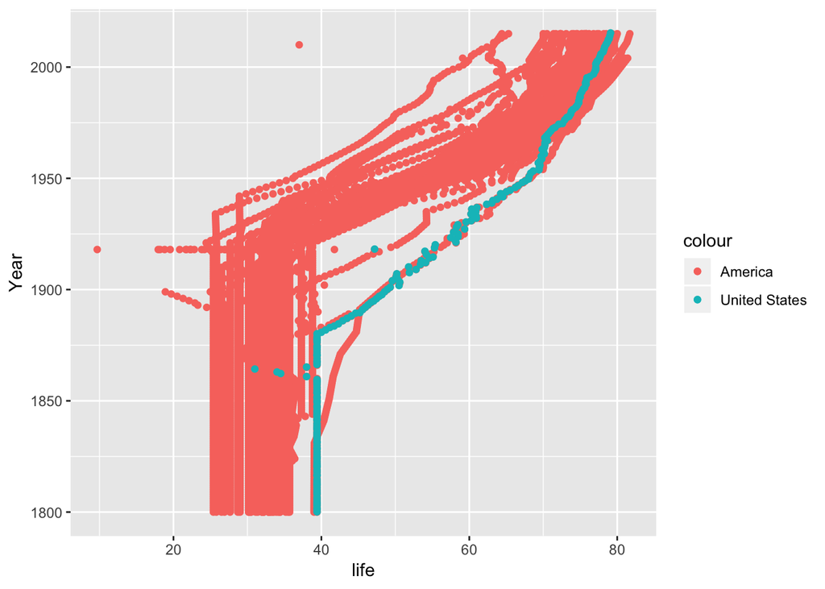

```r
ggplot(data= life_USA, mapping = aes(y=Year, x=life, color="United States")) + geom_point(data = life_America, aes(color="America")) + geom_jitter()
```

While comparing United States to America, the Life expectancy of United States is higher than most of other countries in the same region since the beginning.

## Summary

**Life Expectancy**  
We find that life expectancy in the given dataset is higher in the range of 25-35 years. The mean of Life Expectancy in 2015 for Sub-Saharan Africa region is lower than all other regions, while Europe & Central Asia is highest. **There is a relationship between Life Exepectancy and income. As the life expectancy grows above 60, the income levels rises higher.** When magnified the analysis to American region, the life Expectancy is nearly 75%. Though the average life expectancy of America improve from below average to above average from 1800 to 2015, the life expectancy of United States has been highest than most of the American countries from 1800 to 2015.

**Population**  
We see that India and China are higher in population than other countries. **There is a exponential growth in these countries after 1950.** We also saw that population causes a flattening effect on life expectancy (over 600 million) and also extreme population (over 1 billion) witnesses an increased growth in income.